# Market Basket Association Rules

Neha

4/11/2017

##### Introduction

The goal of market basket analysis is to find what things go together, provide information to guide product placement in stores, cross-category and co-marketing promotions.

```r
# Association Rules for Market Basket Analysis (R)

library(arules)  # association rules
```

```r
library(arulesViz)  # data visualization of association rules
library(RColorBrewer)  # color palettes for plots
```

We use grocery data set, which represents one month transaction data from a grocery outlet. The data set consists of N = 9835 market maskets across K = 169 genreically labelled grocery items.

```r
data(Groceries)  # grocery transactions object from arules package

# show the dimensions of the transactions object
print(dim(Groceries))
```

```
## [1] 9835  169
```

```r
print(dim(Groceries)[1])  # 9835 market baskets for shopping trips
```

```
## [1] 9835
```

```r
print(dim(Groceries)[2])
```

```
## [1] 169
```

A key challenge in market basket analysis and association rule modeling is the sheer number of rules that are generated. An association rule is a division of each item set into two subsets with one subset, the antecedent, thought of as preceeding the other subset, the consequent.

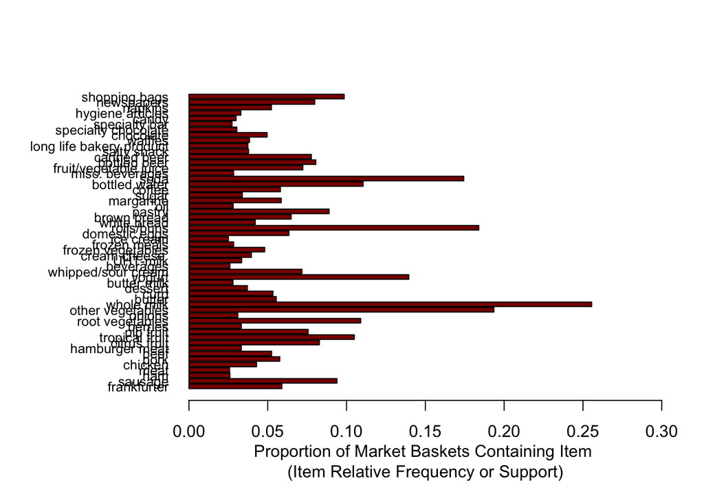

```r
itemFrequencyPlot(Groceries, support = 0.025, cex.names=0.8, xlim = c(0,0.3),
                  type = "relative", horiz = TRUE, col = "dark red", las = 1,
                  xlab = paste("Proportion of Market Baskets Containing Item",
                               "\n(Item Relative Frequency or Support)"))
```

```r
# explore possibilities for combining similar items
print(head(itemInfo(Groceries)))
```

```
##              labels  level2           level1
## 1       frankfurter sausage meat and sausage
## 2           sausage sausage meat and sausage
## 3        liver loaf sausage meat and sausage
## 4               ham sausage meat and sausage
## 5              meat sausage meat and sausage
## 6 finished products sausage meat and sausage
```

```r
print(levels(itemInfo(Groceries)[["level1"]]))  # 10 levels... too few
```

```
##  [1] "canned food"          "detergent"            "drinks"
##  [4] "fresh products"       "fruit and vegetables" "meat and sausage"
##  [7] "non-food"             "perfumery"            "processed food"
## [10] "snacks and candies"
```

```r
print(levels(itemInfo(Groceries)[["level2"]]))  # 55 distinct levels
```

```
##  [1] "baby food"                       "bags"
##  [3] "bakery improver"                 "bathroom cleaner"
##  [5] "beef"                            "beer"
##  [7] "bread and backed goods"          "candy"
##  [9] "canned fish"                     "canned fruit/vegetables"
## [11] "cheese"                          "chewing gum"
## [13] "chocolate"                       "cleaner"
## [15] "coffee"                          "condiments"
## [17] "cosmetics"                       "dairy produce"
## [19] "delicatessen"                    "dental care"
## [21] "detergent/softener"              "eggs"
## [23] "fish"                            "frozen foods"
## [25] "fruit"                           "games/books/hobby"
## [27] "garden"                          "hair care"
## [29] "hard drinks"                     "health food"
## [31] "jam/sweet spreads"               "long-life bakery products"
## [33] "meat spreads"                    "non-alc. drinks"
## [35] "non-food house keeping products" "non-food kitchen"
## [37] "packaged fruit/vegetables"       "perfumery"
## [39] "personal hygiene"                "pet food/care"
## [41] "pork"                            "poultry"
## [43] "pudding powder"                  "sausage"
## [45] "seasonal products"               "shelf-stable dairy"
## [47] "snacks"                          "soap"
## [49] "soups/sauces"                    "staple foods"
## [51] "sweetener"                       "tea/cocoa drinks"
## [53] "vegetables"                      "vinegar/oils"
## [55] "wine"
```

```r
# aggregate items using the 55 level2 levels for food categories
# to create a more meaningful set of items
groceries <- aggregate(Groceries, itemInfo(Groceries)[["level2"]])
```

```r
print(dim(groceries)[1])  # 9835 market baskets for shopping trips
```

```
## [1] 9835
```

```r
print(dim(groceries)[2])  # 55 final store items (categories)
```

```
## [1] 55
```

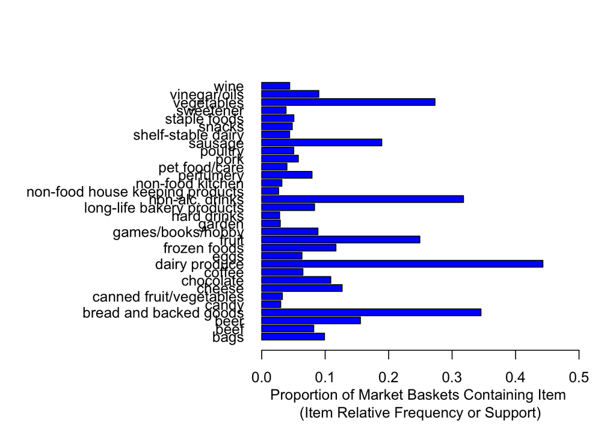

```r
itemFrequencyPlot(groceries, support = 0.025, cex.names=1.0, xlim = c(0,0.5),
                  type = "relative", horiz = TRUE, col = "blue", las = 1,
                  xlab = paste("Proportion of Market Baskets Containing Item",
                               "\n(Item Relative Frequency or Support)"))
```

##### Apriori Algorithm

This algorithm deals with large number of association rules problem by using selection criteria that reflect the potential utility of association rules. The first criteria is referred to as ‘support’ of an item. It determines the proportion of times an item occurs in store data set. The second criteria is ‘confidence’ or predictability of an association rule. This is computed as the support of an item set divided by the support of the subset of items in antecedent.

```r
first.rules <- apriori(groceries,
                       parameter = list(support = 0.001, confidence = 0.05))
```

```
## Apriori
##
## Parameter specification:
##  confidence minval smax arem  aval originalSupport maxtime support minlen
##        0.05    0.1    1 none FALSE            TRUE       5   0.001      1
##  maxlen target   ext
##      10  rules FALSE
##
## Algorithmic control:
##  filter tree heap memopt load sort verbose
##     0.1 TRUE TRUE  FALSE TRUE    2    TRUE
##
## Absolute minimum support count: 9
##
## set item appearances ...[0 item(s)] done [0.00s].
## set transactions ...[55 item(s), 9835 transaction(s)] done [0.00s].
## sorting and recoding items ... [54 item(s)] done [0.00s].
## creating transaction tree ... done [0.00s].
## checking subsets of size 1 2 3 4 5 6 7 8 done [0.01s].
## writing ... [69921 rule(s)] done [0.01s].
## creating S4 object  ... done [0.02s].
```

```r
print(summary(first.rules))  # yields 69,921 rules... too many
```

```
## set of 69921 rules
##
## rule length distribution (lhs + rhs):sizes
##     1     2     3     4     5     6     7     8
##    21  1205 10467 23895 22560  9888  1813    72
##
##    Min. 1st Qu.  Median    Mean 3rd Qu.    Max.
##   1.000   4.000   4.000   4.502   5.000   8.000
##
## summary of quality measures:
##     support           confidence          lift
##  Min.   :0.001017   Min.   :0.0500   Min.   : 0.4475
##  1st Qu.:0.001118   1st Qu.:0.2110   1st Qu.: 1.8315
##  Median :0.001525   Median :0.4231   Median : 2.2573
##  Mean   :0.002488   Mean   :0.4364   Mean   : 2.5382
##  3rd Qu.:0.002339   3rd Qu.:0.6269   3rd Qu.: 2.9662
##  Max.   :0.443010   Max.   :1.0000   Max.   :16.1760
##
## mining info:
##       data ntransactions support confidence
##  groceries          9835   0.001       0.05
```

```r
# select association rules using thresholds for support and confidence
second.rules <- apriori(groceries,
                        parameter = list(support = 0.025, confidence = 0.05))
```

```
## Apriori
##
## Parameter specification:
##  confidence minval smax arem  aval originalSupport maxtime support minlen
##        0.05    0.1    1 none FALSE            TRUE       5   0.025      1
##  maxlen target   ext
##      10  rules FALSE
##
## Algorithmic control:
##  filter tree heap memopt load sort verbose
##     0.1 TRUE TRUE  FALSE TRUE    2    TRUE
##
## Absolute minimum support count: 245
##
## set item appearances ...[0 item(s)] done [0.00s].
## set transactions ...[55 item(s), 9835 transaction(s)] done [0.00s].
## sorting and recoding items ... [32 item(s)] done [0.00s].
## creating transaction tree ... done [0.00s].
## checking subsets of size 1 2 3 4 done [0.00s].
## writing ... [344 rule(s)] done [0.00s].
## creating S4 object  ... done [0.00s].
```

```r
print(summary(second.rules))
```

```
## set of 344 rules
##
## rule length distribution (lhs + rhs):sizes
##   1   2   3   4
##  21 162 129  32
##
##    Min. 1st Qu.  Median    Mean 3rd Qu.    Max.
##     1.0     2.0     2.0     2.5     3.0     4.0
##
## summary of quality measures:
##     support          confidence           lift
##  Min.   :0.02542   Min.   :0.05043   Min.   :0.6669
##  1st Qu.:0.03030   1st Qu.:0.18202   1st Qu.:1.2498
##  Median :0.03854   Median :0.39522   Median :1.4770
##  Mean   :0.05276   Mean   :0.37658   Mean   :1.4831
##  3rd Qu.:0.05236   3rd Qu.:0.51271   3rd Qu.:1.7094
##  Max.   :0.44301   Max.   :0.79841   Max.   :2.4073
##
## mining info:
##       data ntransactions support confidence
##  groceries          9835   0.025       0.05
```

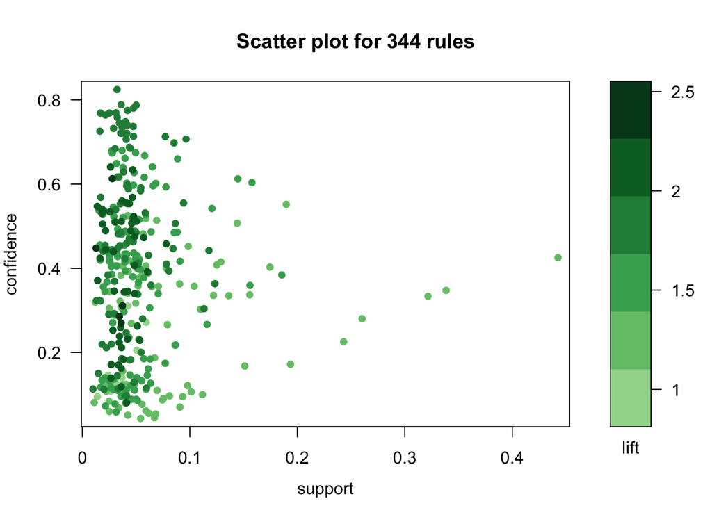

```r
plot(second.rules,
     control=list(jitter=2, col = rev(brewer.pal(9, "Greens")[4:9])),
     shading = "lift")
```

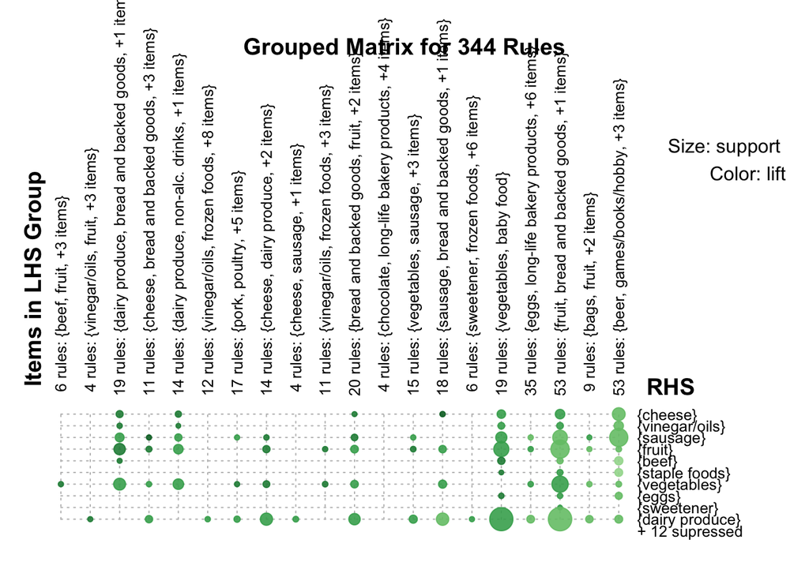

```r
plot(second.rules, method="grouped",
     control=list(col = rev(brewer.pal(9, "Greens")[4:9])))
```

```r
vegie.rules <- subset(second.rules, subset = rhs %pin% "vegetables")
inspect(vegie.rules)  # 41 rules
```

```
##      lhs                            rhs             support confidence      lift
## [1]  {}                          => {vegetables} 0.27300458  0.2730046 1.0000000
## [2]  {poultry}                   => {vegetables} 0.02897814  0.5745968 2.1047148
## [3]  {pork}                      => {vegetables} 0.03009659  0.5220459 1.9122238
## [4]  {staple foods}              => {vegetables} 0.02613116  0.5160643 1.8903136
## [5]  {eggs}                      => {vegetables} 0.03141840  0.4951923 1.8138608
## [6]  {games/books/hobby}         => {vegetables} 0.02785968  0.3145809 1.1522918
## [7]  {long-life bakery products} => {vegetables} 0.02907982  0.3492063 1.2791227
## [8]  {perfumery}                 => {vegetables} 0.03213015  0.4056483 1.4858662
## [9]  {beef}                      => {vegetables} 0.04585663  0.5595533 2.0496116
## [10] {bags}                      => {vegetables} 0.03141840  0.3175745 1.1632571
## [11] {vinegar/oils}              => {vegetables} 0.04199288  0.4666667 1.7093731
## [12] {chocolate}                 => {vegetables} 0.03192679  0.2934579 1.0749195
## [13] {beer}                      => {vegetables} 0.03406202  0.2189542 0.8020168
## [14] {frozen foods}              => {vegetables} 0.04738180  0.4052174 1.4842879
## [15] {cheese}                    => {vegetables} 0.05531266  0.4365971 1.5992300
## [16] {sausage}                   => {vegetables} 0.07625826  0.4032258 1.4769929
## [17] {fruit}                     => {vegetables} 0.10706660  0.4297959 1.5743176
## [18] {non-alc. drinks}           => {vegetables} 0.09456024  0.2974097 1.0893944
## [19] {bread and backed goods}    => {vegetables} 0.11621759  0.3363743 1.2321198
## [20] {dairy produce}             => {vegetables} 0.17041179  0.3846683 1.4090180
## [21] {beef,
##       dairy produce}             => {vegetables} 0.02989324  0.6074380 2.2250104
## [22] {dairy produce,
##       vinegar/oils}              => {vegetables} 0.03141840  0.5355286 1.9616103
## [23] {dairy produce,
##       frozen foods}              => {vegetables} 0.03436706  0.5121212 1.8758704
## [24] {cheese,
##       fruit}                     => {vegetables} 0.02674123  0.5197628 1.9038613
## [25] {bread and backed goods,
##       cheese}                    => {vegetables} 0.02887646  0.4536741 1.6617821
## [26] {cheese,
##       dairy produce}             => {vegetables} 0.04219624  0.4987981 1.8270686
## [27] {fruit,
##       sausage}                   => {vegetables} 0.03426538  0.5290424 1.9378517
## [28] {non-alc. drinks,
##       sausage}                   => {vegetables} 0.03029995  0.4156206 1.5223944
## [29] {bread and backed goods,
##       sausage}                   => {vegetables} 0.04382308  0.4229637 1.5492916
## [30] {dairy produce,
```

[output cut: 13 more lines]

```
## [37] {dairy produce,
##       fruit,
##       sausage}                   => {vegetables} 0.02714794  0.5741935 2.1032378
## [38] {bread and backed goods,
##       dairy produce,
##       sausage}                   => {vegetables} 0.03284189  0.5135135 1.8809704
## [39] {dairy produce,
##       fruit,
##       non-alc. drinks}           => {vegetables} 0.03304525  0.5183413 1.8986543
## [40] {bread and backed goods,
##       dairy produce,
##       fruit}                     => {vegetables} 0.04077275  0.5276316 1.9326840
## [41] {bread and backed goods,
##       dairy produce,
##       non-alc. drinks}           => {vegetables} 0.03345196  0.4627286 1.6949480
```

```r
# sort by lift and identify the top 10 rules
top.vegie.rules <- head(sort(vegie.rules, decreasing = TRUE, by = "lift"), 10)
inspect(top.vegie.rules)
```

```
##      lhs                         rhs             support confidence     lift
## [1]  {beef,
##       dairy produce}          => {vegetables} 0.02989324  0.6074380 2.225010
## [2]  {poultry}                => {vegetables} 0.02897814  0.5745968 2.104715
## [3]  {dairy produce,
##       fruit,
##       sausage}                => {vegetables} 0.02714794  0.5741935 2.103238
## [4]  {beef}                   => {vegetables} 0.04585663  0.5595533 2.049612
## [5]  {dairy produce,
##       vinegar/oils}           => {vegetables} 0.03141840  0.5355286 1.961610
## [6]  {fruit,
##       sausage}                => {vegetables} 0.03426538  0.5290424 1.937852
## [7]  {bread and backed goods,
##       dairy produce,
##       fruit}                  => {vegetables} 0.04077275  0.5276316 1.932684
## [8]  {pork}                   => {vegetables} 0.03009659  0.5220459 1.912224
## [9]  {cheese,
##       fruit}                  => {vegetables} 0.02674123  0.5197628 1.903861
## [10] {dairy produce,
##       fruit,
##       non-alc. drinks}        => {vegetables} 0.03304525  0.5183413 1.898654
```

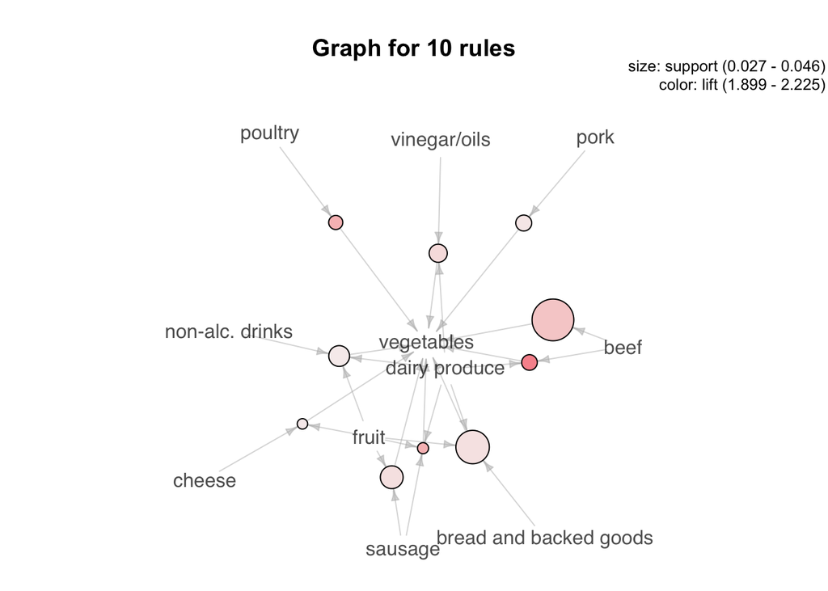

```r
plot(top.vegie.rules, method="graph",
     control=list(type="items"),
     shading = "lift")
```